# Abrupt versus Gradual Motor Learning

# Load Packages

```r
library(svglite)
library(optimx)
library(ez)
library(ggplot2)
```

# Load R scripts

```r
source('orderEffects.R') # this file deals with the order effects and runs the ANOVA
source('ExtentofLearning.R') # this file deals with the extent of learning and runs the ANOVA
source('Figures.R') # this file creates the 4 figures
source('ReboundANOVA.R') #this file has the ANOVAs for the rebounds
```

# Overview

This document discusses the figures and statistics used to investigate abrupt versus gradual motor learning. The main sections here will be looking at the Order Effects, the Extent of Learning, and the Rebound.

# Plotting All of the Behavioural Data

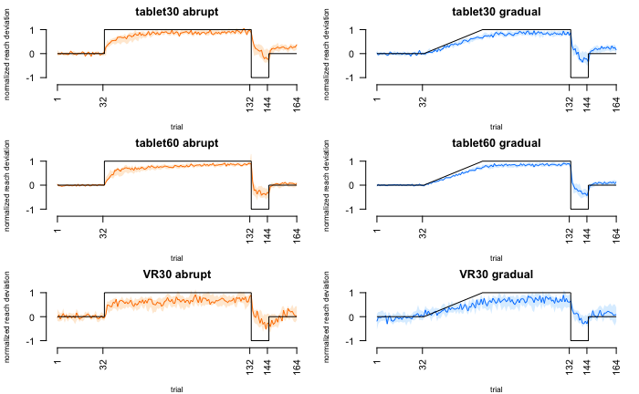

```r
plotAllData()
```

# Order Effects of Within-Subjects Design

## Plotting Order Data

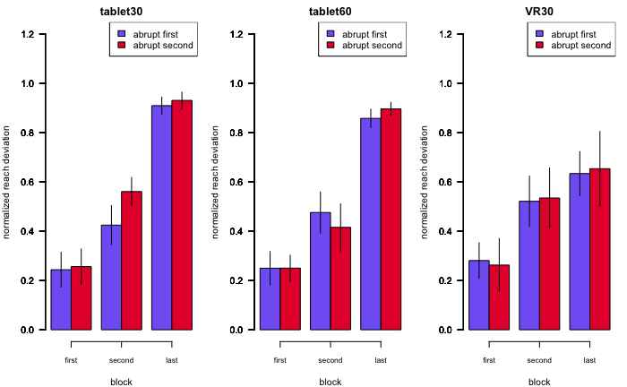

```r
plotOrderData()
```

## Statistics on order data

### first block:

Here is the 2x2 ANOVA on the first block of the training phase with setup (tablet30, VR30) and order as our between subjects factors.

```r
setup_order_first_ANOVA()
```

```
Data is unbalanced (unequal N per group). Make sure you specified a well-considered value for the type argument to ezANOVA().Coefficient covariances computed by hccm()
```

```
$ANOVA
       Effect DFn DFd            F         p p<.05          ges
1       setup   1  45 7.517479e-02 0.7852009       0.0016677648
2       order   1  45 8.675569e-05 0.9926096       0.0000019279
3 setup:order   1  45 3.707611e-02 0.8481765       0.0008232354

$`Levene's Test for Homogeneity of Variance`
  DFn DFd         SSn      SSd         F         p p<.05
1   3  45 0.003589728 1.791413 0.0300578 0.9928865
```

Here is the 2x2 ANOVA on the first block of the training phase with rotation (tablet30, tablet60) and order as our between subjects factors.

```r
rotation_order_first_ANOVA()
```

```
Data is unbalanced (unequal N per group). Make sure you specified a well-considered value for the type argument to ezANOVA().Coefficient covariances computed by hccm()
```

```
$ANOVA
          Effect DFn DFd            F         p p<.05          ges
1       rotation   1  54 4.433960e-08 0.9998328       8.211037e-10
2          order   1  54 1.047404e-02 0.9188637       1.939261e-04
3 rotation:order   1  54 8.733415e-03 0.9258898       1.617037e-04

$`Levene's Test for Homogeneity of Variance`
  DFn DFd         SSn      SSd          F         p p<.05
1   3  54 0.009090661 1.790872 0.09136994 0.9644904
```

### second block:

Here is the 2x2 ANOVA on the second block of the training phase with setup (tablet30, VR30) and order as our between subjects factors.

```r
setup_order_second_ANOVA()
```

```
Data is unbalanced (unequal N per group). Make sure you specified a well-considered value for the type argument to ezANOVA().Coefficient covariances computed by hccm()
```

```
$ANOVA
       Effect DFn DFd         F         p p<.05         ges
1       setup   1  45 0.1813596 0.6722375       0.004014035
2       order   1  45 1.0792741 0.3044101       0.023422117
3 setup:order   1  45 0.4903144 0.4873917       0.010778436

$`Levene's Test for Homogeneity of Variance`
  DFn DFd        SSn      SSd         F        p p<.05
1   3  45 0.06857067 1.976227 0.5204665 0.670374
```

Here is the 2x2 ANOVA on the second block of the training phase with rotation (tablet30, tablet60) and order as our between subjects factors.

```r
rotation_order_second_ANOVA()
```

```
Data is unbalanced (unequal N per group). Make sure you specified a well-considered value for the type argument to ezANOVA().Coefficient covariances computed by hccm()
```

```
$ANOVA
          Effect DFn DFd         F         p p<.05         ges
1       rotation   1  54 0.3496452 0.5567813       0.006433256
2          order   1  54 0.2706992 0.6049898       0.004987944
3 rotation:order   1  54 1.5241497 0.2223380       0.027450212

$`Levene's Test for Homogeneity of Variance`
  DFn DFd       SSn     SSd         F        p p<.05
1   3  54 0.1040763 1.92981 0.9707552 0.413331
```

### final block:

Here is the 2x2 ANOVA on the last block of the training phase with setup (tablet30, VR30) and order as our between subjects factors.

```r
setup_order_last_ANOVA()
```

```
Data is unbalanced (unequal N per group). Make sure you specified a well-considered value for the type argument to ezANOVA().Coefficient covariances computed by hccm()
```

```
$ANOVA
       Effect DFn DFd            F            p p<.05          ges
1       setup   1  45 1.403321e+01 0.0005088901     * 2.377172e-01
2       order   1  45 8.285122e-02 0.7747916047       1.837755e-03
3 setup:order   1  45 1.055228e-04 0.9918493387       2.344945e-06

$`Levene's Test for Homogeneity of Variance`
  DFn DFd     SSn      SSd        F           p p<.05
1   3  45 0.37747 1.176885 4.811049 0.005450052     *
```

### final block:

Here is the 2x2 ANOVA on the last block of the training phase with rotation (tablet30, tablet60) and order as our between subjects factors.

```r
rotation_order_last_ANOVA()
```

```
Data is unbalanced (unequal N per group). Make sure you specified a well-considered value for the type argument to ezANOVA().Coefficient covariances computed by hccm()
```

```
$ANOVA
          Effect DFn DFd          F         p p<.05         ges
1       rotation   1  54 1.66485575 0.2024469       0.029908561
2          order   1  54 0.78070381 0.3808429       0.014251438
3 rotation:order   1  54 0.06487721 0.7999146       0.001199988

$`Levene's Test for Homogeneity of Variance`
  DFn DFd         SSn       SSd         F         p p<.05
1   3  54 0.002300623 0.2941218 0.1407962 0.9351133
```

# Extent of Learning

Here we are checking if there are any differences in the extent of learning in the abrupt and gradual conditions during the last training and last reversal blocks. The data is shown for the 3 groups (30° digitizing tablet, 60° digitalizing tablet, 30° VR setups). The orange bars here represent the mean reach deviations of the abrupt condition, and the blue bars represent the mean reach deviations of gradual condition. All of the data has been normalized to the size of the rotation.

## Plotting Extent of Learning

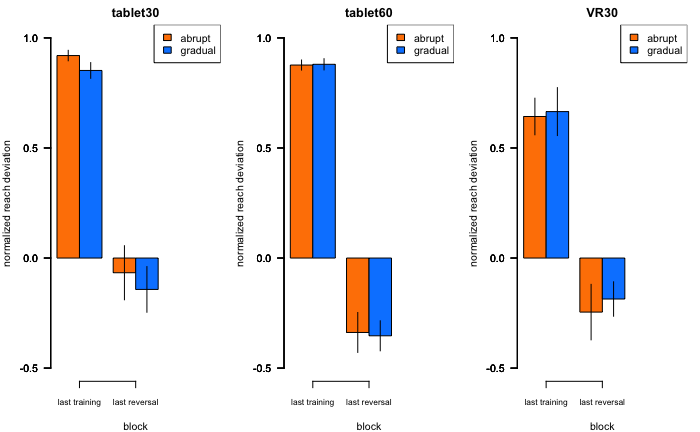

```r
plotExtentofLearning()
```

## Statistics for Extent of Learning

### last block of the training phase:

Here is the 2x2 ANOVA on the last block of the training phase with setup (tablet30, VR30) as our between subjects factor and condition (abrupt, gradual) as our within-subjects factor.

```r
setupLastTrainingANOVA()
```

```
Data is unbalanced (unequal N per group). Make sure you specified a well-considered value for the type argument to ezANOVA().
```

```
$ANOVA
           Effect DFn DFd          F            p p<.05         ges
2           setup   1  47 14.5655912 0.0003947903     * 0.135021569
3       condition   1  47  0.3114509 0.5794400832       0.003278042
4 setup:condition   1  47  0.5557560 0.4596874362       0.005834367
```

Here is the 2x2 ANOVA on the last block of the training phase with rotation size (tablet30, tablet60) as our between subjects factor and condition (abrupt, gradual) as our within-subjects factor.

```r
rotationLastTrainingANOVA()
```

```
Data is unbalanced (unequal N per group). Make sure you specified a well-considered value for the type argument to ezANOVA().
```

```
$ANOVA
              Effect DFn DFd         F         p p<.05          ges
2           rotation   1  56 0.0664637 0.7975020       0.0006688023
3          condition   1  56 1.6698185 0.2015899       0.0128371730
4 rotation:condition   1  56 1.8893761 0.1747481       0.0145006050
```

### last block of the reversal phase:

Here is the 2x2 ANOVA on the last block of the reversal phase with setup (tablet30, VR30) as our between subjects factor and condition (abrupt, gradual) as our within-subjects factor.

```r
setupLastReversalANOVA()
```

```
Data is unbalanced (unequal N per group). Make sure you specified a well-considered value for the type argument to ezANOVA().
```

```
$ANOVA
           Effect DFn DFd          F         p p<.05          ges
2           setup   1  47 0.66169357 0.4200646       0.0094984816
3       condition   1  47 0.06553617 0.7990677       0.0004444087
4 setup:condition   1  47 0.52223131 0.4734722       0.0035303801
```

Here is the 2x2 ANOVA on the last block of the reversal phase with rotation size (tablet30, tablet60) as our between subjects factor and condition (abrupt, gradual) as our within-subjects factor.

```r
rotationLastReversalANOVA()
```

```
Data is unbalanced (unequal N per group). Make sure you specified a well-considered value for the type argument to ezANOVA().
```

```
$ANOVA
              Effect DFn DFd         F          p p<.05          ges
2           rotation   1  56 3.8512554 0.05468455       0.0496695156
3          condition   1  56 0.4542212 0.50310972       0.0019430584
4 rotation:condition   1  56 0.1926988 0.66236899       0.0008252463
```

# Rebound

Here we are checking if there are any differences in the rebound between the abrupt and gradual conditions for the 3 groups (30° digitizing tablet, 60° digitalizing tablet, 30° VR setups). The orange bars here represent the mean reach deviations of the abrupt condition, and the blue bars represent the mean reach deviations of gradual condition. All of the data has been normalized to the size of the rotation.

## Plotting Rebound

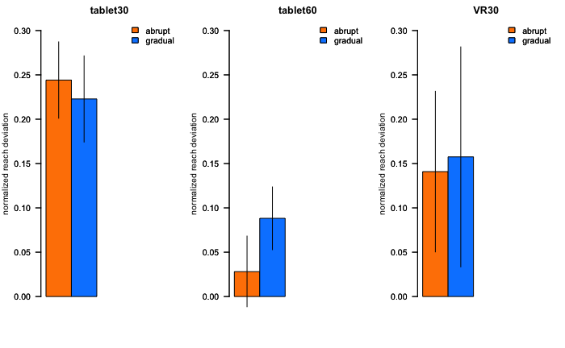

```r
plotReboundData()
```

## Statistics on Rebound

Here is the 2x2 ANOVA on the rebound with setup (tablet30, VR30) as our between subjects factor and condition (abrupt, gradual) as our within-subjects factor.

```r
setupReboundANOVA()
```

```
Data is unbalanced (unequal N per group). Make sure you specified a well-considered value for the type argument to ezANOVA().
```

```
$ANOVA
           Effect DFn DFd           F         p p<.05          ges
2           setup   1  47 1.194170708 0.2800596       1.389171e-02
3       condition   1  47 0.009604493 0.9223471       9.104023e-05
4 setup:condition   1  47 0.075266249 0.7850203       7.129990e-04
```

### Normalized Data:

Here is the 2x2 ANOVA on the rebound with rotation size (tablet30, tablet60) as our between subjects factor and condition (abrupt, gradual) as our within-subjects factor. These rebounds have been normalized to the rotation size.

```r
rotationReboundANOVA()
```

```
Data is unbalanced (unequal N per group). Make sure you specified a well-considered value for the type argument to ezANOVA().
```

```
$ANOVA
              Effect DFn DFd          F            p p<.05         ges
2           rotation   1  57 14.2558022 0.0003827086     * 0.131407866
3          condition   1  57  0.2490659 0.6196543344       0.001723414
4 rotation:condition   1  57  1.1780314 0.2823262885       0.008099336
```

### Not Normalized Data

Here is the 2x2 ANOVA on the rebound with rotation size (tablet30, tablet60) as our between subjects factor and condition (abrupt, gradual) as our within-subjects factor. These rebounds here have not been normalized to the rotation size.

```r
rotationReboundANOVA()
```

[output not shown]

### paired t-test for each group:

Here is a paired t-test comparing the abrupt and gradual conditions in the tablet30 group.

```r
getReboundTtest(group = 'tablet30')
```

```
    Paired t-test

data:  x and y
t = 0.3902, df = 29, p-value = 0.6992
alternative hypothesis: true difference in means is not equal to 0
95 percent confidence interval:
 -0.0904250  0.1330629
sample estimates:
mean of the differences
             0.02131896
```

Here is a paired t-test comparing the abrupt and gradual conditions in the tablet60 group.

```r
getReboundTtest(group = 'tablet60')
```

```
    Paired t-test

data:  x and y
t = -1.172, df = 28, p-value = 0.2511
alternative hypothesis: true difference in means is not equal to 0
95 percent confidence interval:
 -0.16530566  0.04498778
sample estimates:
mean of the differences
            -0.06015894
```

Here is a paired t-test comparing the abrupt and gradual conditions in the VR30 group.

```r
getReboundTtest(group = 'VR30')
```

```
    Paired t-test

data:  x and y
t = -0.10966, df = 18, p-value = 0.9139
alternative hypothesis: true difference in means is not equal to 0
95 percent confidence interval:
 -0.3351880  0.3019316
sample estimates:
mean of the differences
            -0.01662817
```

Here is a one-sample t-test with the rebound from the abrupt condition in the tablet30 group.

```r
abrupt_ReboundTtest(group = 'tablet30')
```

[output not shown]

Here is a one-sample t-test with the rebound from the gradual condition in the tablet30 group.

```r
gradual_ReboundTtest(group = 'tablet30')
```

[output not shown]

Here is a one-sample t-test with the rebound from the abrupt condition in the tablet60 group.

```r
abrupt_ReboundTtest(group = 'tablet60')
```

[output not shown]

Here is a one-sample t-test with the rebound from the gradual condition in the tablet60 group.

```r
gradual_ReboundTtest(group = 'tablet60')
```

[output not shown]